# Differential Expression Analysis

# Normalizando los datos

```r
library("edgeR")
dge <- DGEList(
    counts = assay(rseProjectTB, "counts"),
    genes = rowData(rseProjectTB)
)
#calculando los factores de normalizacion para nuestros datos
dge <- calcNormFactors(dge)
```

Intentemos visualizar la relacion entre nuestras variables antes de comenzar el analisis de expresion diferencial.

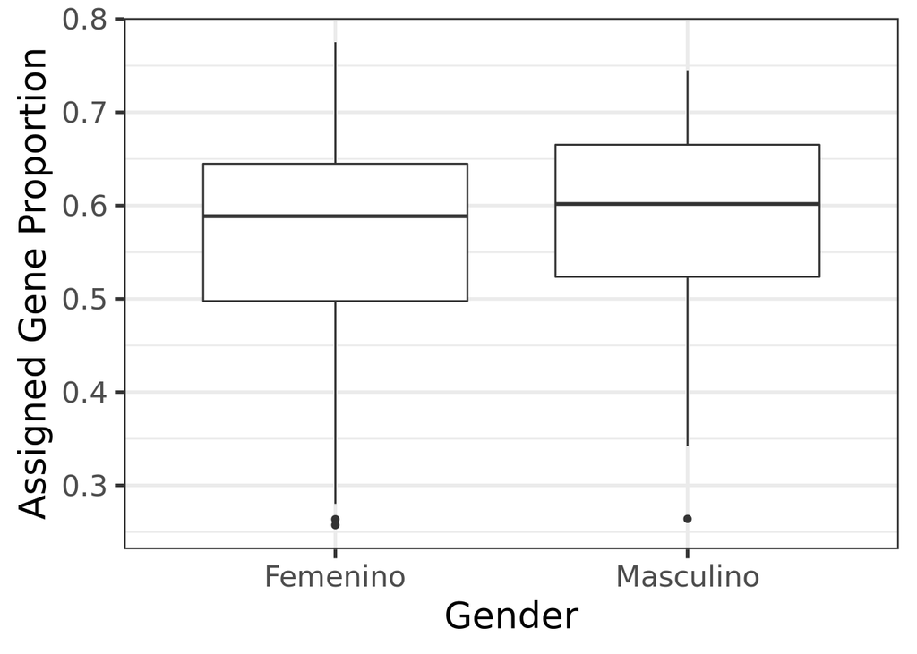

```r
library("ggplot2")
ggplot(as.data.frame(colData(rseProjectTB)), aes(y = assigned_gene_prop,
                                               x = rseProjectTB$Femenino)) +
    geom_boxplot() +
    theme_bw(base_size = 20) +
    ylab("Assigned Gene Proportion") +
    xlab("Gender")
```

La cantidad de muestras en nuestros datos es muy grande, asi que unque la grafica anterior parezca no mostrar una diferencia marcada en proporciones de expresion, podemos seguir con nuestro analisis y predecir que esta diferencia se correlacione a el genero de los participantes.

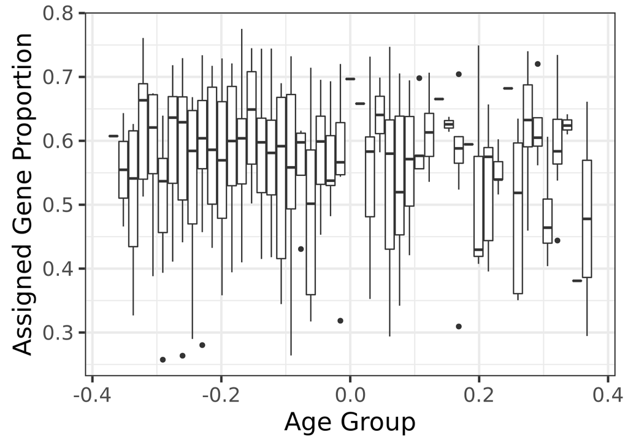

```r
library("ggplot2")
ggplot(as.data.frame(colData(rseProjectTB)), aes(y = assigned_gene_prop,
                                               group = rseProjectTB$sra_attribute.age)) +
    geom_boxplot() +
    theme_bw(base_size = 20) +
    ylab("Assigned Gene Proportion") +
    xlab("Age Group")
```

# Creamos el modelo estadistico usando la funcion ‘model.matrix()’.

```r
statModel <- model.matrix(~ Femenino + sra_attribute.age + assigned_gene_prop,
    data = colData(rseProjectTB)
)
colnames(statModel)
```

```
## [1] "(Intercept)"        "FemeninoMasculino"  "sra_attribute.age"
## [4] "assigned_gene_prop"
```

# Realizamos el analisis diferencial utilizando el paquete ‘limma’.

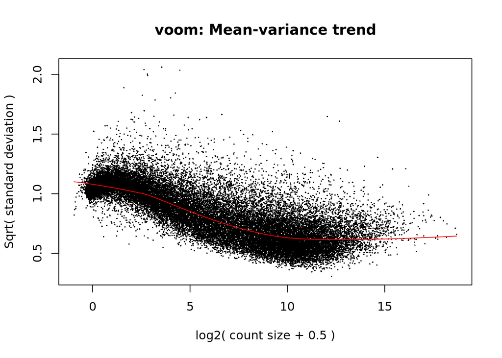

```r
library("limma")
vGene <- voom(dge, statModel, plot = TRUE)
```

El metodo de ‘voom’ nos muestra que la desviacion estandard de los valores de expresion de nuestros genes un ajuste para obtener valores ‘p’ mas estables.

Realizamos un modelo de regresion lineal con la funcion ‘lmFit’ y utilizamos este modelo para obtener los estadisticos de nuestros datos con la funcion ‘eBayes’.

```r
eBresults <- eBayes(lmFit(vGene))

#resultado de los genes con expresion diferencial
deResults <- topTable(
    eBresults,
    coef = 2,
    number = nrow(rseProjectTB),
    sort.by = "none"
)

dim(deResults)
```

```
## [1] 31972    16
```

Mostramos los genes diferencialmente expresados entre hombres y mujeres con FDR < 5%

```r
table(deResults$adj.P.Val < 0.05)
```

```
##
## FALSE  TRUE
## 27175  4797
```

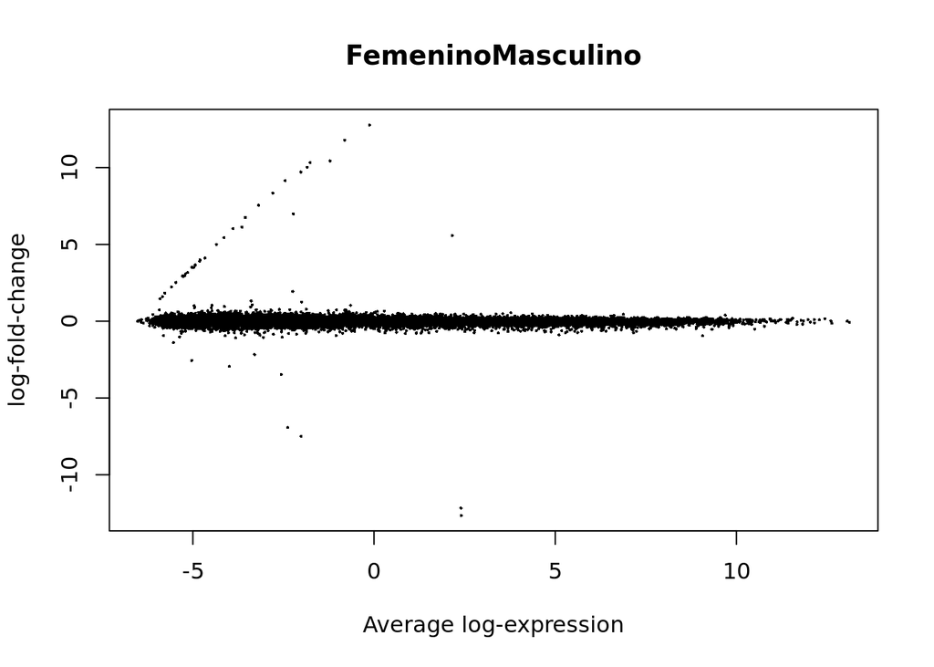

```r
# Visualicemos los resultados estadísticos
limma::plotMA(eBresults, coef = 2)
```

# Visualizacion

Visualizaremos los 50 genes con una mayor expresion diferencial.

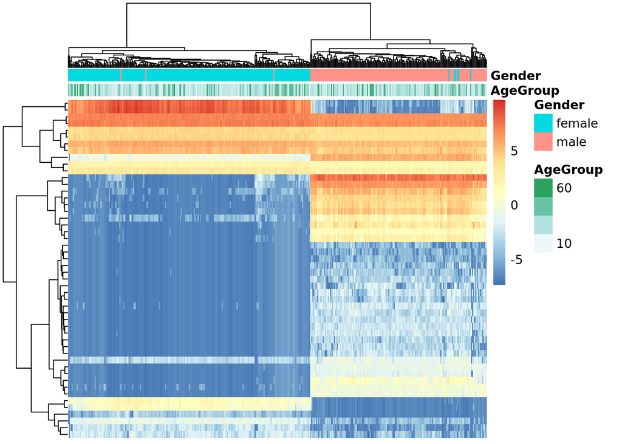

```r
# Extraemos valores de los top 50 genes
exprs_heatmap <- vGene$E[rank(deResults$adj.P.Val) <= 50, ]

## Creemos una tabla con información de las muestras
## y con nombres de las columnas
df <- as.data.frame(colData(rseProjectTB)[, c("sra_attribute.age", "sra_attribute.gender")])
colnames(df) <- c("AgeGroup", "Gender")

# Visualizamos la expresion diferencial con un heatmap
library("pheatmap")
pheatmap(
    exprs_heatmap,
    cluster_rows = TRUE,
    cluster_cols = TRUE,
    show_rownames = FALSE,
    show_colnames = FALSE,
    annotation_col = df
)
```

Asignamos el nombre de los genes a los renglones y guardamos el heatmap en un pdf.

```r
## Con match() podemos encontrar cual es cual
rownames(exprs_heatmap) <- rowRanges(rseProjectTB)$gene_name[
    match(rownames(exprs_heatmap), rowRanges(rseProjectTB)$gene_id)
]


## Hagamos un heatmap
library("pheatmap")

pdf("pheatmap_.pdf", height = 6, useDingbats = FALSE)
pheatmap(
    exprs_heatmap,
    cluster_rows = TRUE,
    cluster_cols = TRUE,
    show_rownames = TRUE,
    show_colnames = TRUE,
    annotation_col = df
)
```

# Conclusiones

Existen varios conjuntos de genes que se expresan diferencialmente entre los dos generos, siendo el mas obvio el grupo que se muestra en color azul del lado izquierdo, el cual representa los genes con una baja expresion en las mujeres, y el cual hace contraste con dos grupos de genes en los hombres, uno de ellos aumenta en expresion ligeramente, mientras que el segundo muestra niveles marcadamente altos. En la parte superior de la imagen, se muestra un agrupamiento de unos pocos genes con una expresion diferencial muy marcada, estos genes poseen niveles de expresion muy altos en el grupo femenino, sin embargo en los hombres paraecen estar ‘apagados’, este pequeno cluster de genes podria ser el responsable de una diferencia en la progresion de la infeccion en ambos grupos. Justo debajo de este sector, existe un cluster de genes que ambos generos comparten, es probable que estos genes sean parte de la respuesta a la infeccion de Mycobacterium tuberculosis sin importar el genero. La variable de la edad parece no agruparse, por lo que no indica una diferencia clara entre los perfiles de expresion diferencial. Un diseno mas exhaustivo de la matriz y del modelo estadistico podria haber arrojado un poco de luz en esta ultima cuestion y refinado el resultado en cuanto a division por genero.